# R Notebook

# Exercise 9.29

## a.

z = 2/3，經由查表可得約有25%(0.2524)的學生一個月消費至少12塊pizza

## b.

275/25 = 11

z = (11-10)/(3/sqrt(25)) =5/3

經由查表可得知從母體抽出的25位學生中約有5%(0.478)的機率其總消費披薩數至少為275塊

# Exercise 9.35

1140/16 = 71.25

(71.25-75)/(10/sqrt(16)) =-1.5

經由查表可得知從母體抽出的16人中約有93%(0.9332)的機率其總體重會超出電梯的負荷量

# Exercise 9.51

因為np>5(300)且n(1-p)>5(700)滿足rule of five

因此P(p>0.32) = P((p-0.3)/sqrt((p(1-p))/n)>0.02/0.01449) = 0.0838 = 8.38%

# Exercise 9.53

因為同樣滿足rule of five

P(p<0.75) = P((p-0.8)/sqrt((p(1-p))/n)<-0.05/sqrt(0.8*0.2/350)) = P(z<-2.33) = 0.0099 = 0.99%

# Exercise Hw Ch9

```r
genpop1=function(size=10000, mixprob=0.6, m1=100, sd1=10, m2=150, sd2=20) {
    tmpseed = .Random.seed
    set.seed(5523)
    #flip coins with mixprob success prob.
    coin1 = runif(size) < mixprob

    rn1 = rnorm(size, m1, sd1)
    rn2 = rnorm(size, m2, sd2)

    rnfinal = rn2
    rnfinal[coin1] = rn1[coin1]
    .Random.seed = tmpseed
    return(rnfinal)
}

genpop2 = function(size=12000, lambda=140) {
    tmpseed = .Random.seed
    set.seed(5524)
    tmp1 = rpois(size, lambda)
    .Random.seed = tmpseed
    return(tmp1)
}

set.seed(1001) #to get .Random.seed defined.
pop1 = genpop1()
pop2 = genpop2()
```

## 1

calculate the size, mean, amd std for $P_1$ and $P_2$

```r
size1 = length(pop1)
size2 = length(pop2)
std1  = sqrt(var(pop1)*(size1-1)/size1)
std2  = sqrt(var(pop2)*(size2-1)/size2)
mean1 = mean(pop1)
mean2 = mean(pop2)
cat("For P1, the population size is ",size1,", the mean is ", mean1, ", and the standard deviation is ", std1,"\n")
```

```
## For P1, the population size is  10000 , the mean is  120.2431 , and the standard deviation is  28.68514
```

```r
cat("For P2, the population size is ",size2,", the mean is ", mean2, ", and the standard deviation is ", std2)
```

```
## For P2, the population size is  12000 , the mean is  139.8814 , and the standard deviation is  11.87759
```

## 2

draw the histogram of $P_1$ and $P_2$

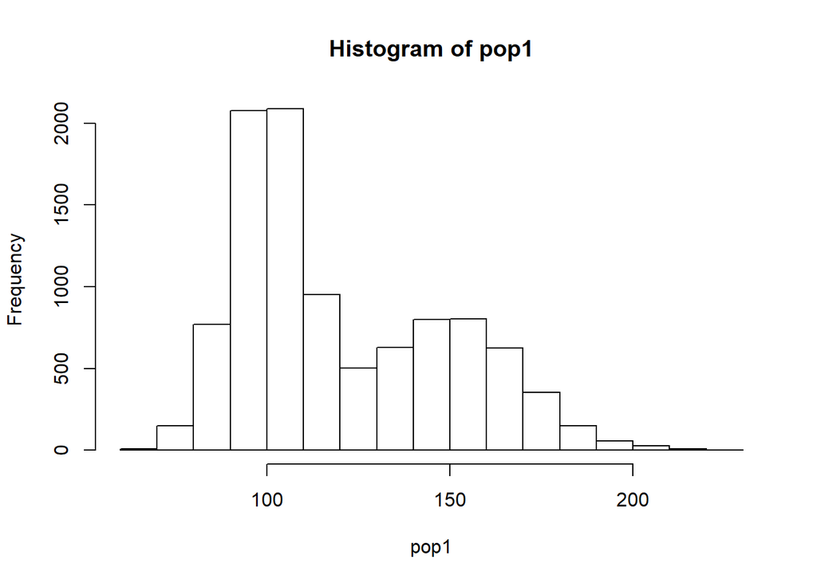

```r
hist(pop1)
```

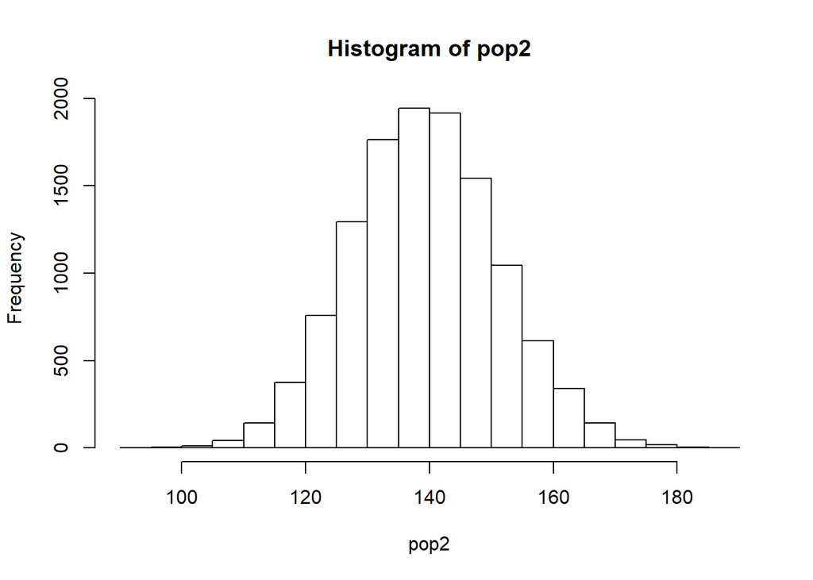

```r
hist(pop2)
```

## 3

compute the mean and standard deviation of $X_1$ bar - $X_2$bar

```r
d = mean1 - mean2
std = sqrt((std1*std1)/100 + (std2*std2)/50)
cat("the mean is ", d,", and the standard deviation is " ,std)
```

```
## the mean is  -19.63828 , and the standard deviation is  3.324141
```

## 4

compute the mean and standard deviation of d after 50 runs

```r
  meanX1 = vector(mode = "numeric", length = 50)
  meanX2 = vector(mode = "numeric", length = 50)
  d = vector(mode = "numeric", length = 50)
  stdlist  = c()
  set.seed(5523)
  for(i in 1:50){
    samP1 <- sample(pop1,100)
    meanX1[i] = mean(samP1)
    samP2 <- sample(pop2,50)
    meanX2[i] = mean(samP2)


  }
  for(i in 1:50){
    d[i] =  meanX1[i] - meanX2[i]
  }
  meanX1X2 = mean(d)
  stdX1X2  = sqrt(var(d)*49/50)
  cat("the mean of X1 - X2 after 50 runs is ",meanX1X2, ", and the std is ", stdX1X2 )
```

```
## the mean of X1 - X2 after 50 runs is  -19.41588 , and the std is  3.441018
```

## 5

compute the mean and standard deviation of d after those runs that the question request

```r
  mean1_50 = vector(mode = "numeric", length = 50)
  mean2_50 = vector(mode = "numeric", length = 50)
  d50 = vector(mode = "numeric", length = 50)
  set.seed(5523)
  for(i in 1:50){
    samP1 <- sample(pop1,100)
    mean1_50[i] = mean(samP1)
    samP2 <- sample(pop2,50)
    mean2_50[i] = mean(samP2)
  }
  for(i in 1:50){
    d50[i] =  mean1_50[i] - mean2_50[i]
  }
  mean50 = mean(d50)
  std50  = sqrt(var(d50)*49/50)


  mean1_100 = vector(mode = "numeric", length = 100)
  mean2_100 = vector(mode = "numeric", length = 100)
  d100 = vector(mode = "numeric", length = 100)
  set.seed(5523)
  for(i in 1:100){
    samP1 <- sample(pop1,100)
    mean1_100[i] = mean(samP1)
    samP2 <- sample(pop2,100)
    mean2_100[i] = mean(samP2)


  }
  for(i in 1:100){
    d100[i] =  mean1_100[i] - mean2_100[i]
  }
  mean100 = mean(d100)
  std100  = sqrt(var(d100)*99/100)


  mean1_500 = vector(mode = "numeric", length = 500)
  mean2_500 = vector(mode = "numeric", length = 500)
  d500 = vector(mode = "numeric", length = 500)
  set.seed(5523)
  for(i in 1:500){
    samP1 <- sample(pop1,100)
    mean1_500[i] = mean(samP1)
    samP2 <- sample(pop2,50)
    mean2_500[i] = mean(samP2)


  }
  for(i in 1:500){
    d500[i] =  mean1_500[i] - mean2_500[i]
  }
  mean500 = mean(d500)
  std500  = sqrt(var(d500)*499/500)


  mean1_1000 = vector(mode = "numeric", length = 1000)
  mean2_1000 = vector(mode = "numeric", length = 1000)
  d1000 = vector(mode = "numeric", length = 1000)
  for(i in 1:1000){
    samP1 <- sample(pop1,100)
    mean1_1000[i] = mean(samP1)
    samP2 <- sample(pop2,50)
    mean2_1000[i] = mean(samP2)


  }
  for(i in 1:1000){
    d1000[i] =  mean1_1000[i] - mean2_1000[i]
  }
  mean1000 = mean(d1000)
  std1000  = sqrt(var(d1000)*999/1000)


  mean1_5000 = vector(mode = "numeric", length = 5000)
  mean2_5000 = vector(mode = "numeric", length = 5000)
  d5000 = vector(mode = "numeric", length = 5000)
  for(i in 1:5000){
    samP1 <- sample(pop1,100)
    mean1_5000[i] = mean(samP1)
    samP2 <- sample(pop2,50)
    mean2_5000[i] = mean(samP2)


  }
  for(i in 1:5000){
    d5000[i] =  mean1_5000[i] - mean2_5000[i]
  }
  mean5000 = mean(d5000)
  std5000  = sqrt(var(d5000)*4999/5000)


  mean1_10000 = vector(mode = "numeric", length = 10000)
  mean2_10000 = vector(mode = "numeric", length = 10000)
  d10000 = vector(mode = "numeric", length = 10000)
  for(i in 1:10000){
    samP1 <- sample(pop1,100)
    mean1_10000[i] = mean(samP1)
    samP2 <- sample(pop2,50)
    mean2_10000[i] = mean(samP2)


  }
  for(i in 1:10000){
    d10000[i] =  mean1_10000[i] - mean2_10000[i]
  }
  mean10000 = mean(d10000)
  std10000  = sqrt(var(d10000)*9999/10000)


  mean1_50000 = vector(mode = "numeric", length = 50000)
  mean2_50000 = vector(mode = "numeric", length = 50000)
  d50000 = vector(mode = "numeric", length = 50000)
  for(i in 1:50000){
    samP1 <- sample(pop1,100)
    mean1_50000[i] = mean(samP1)
    samP2 <- sample(pop2,50)
    mean2_50000[i] = mean(samP2)


  }
  for(i in 1:50000){
    d50000[i] =  mean1_50000[i] - mean2_50000[i]
  }
  mean50000 = mean(d50000)
  std50000  = sqrt(var(d50000)*49999/50000)
  cat("the mean of X1 - X2 after 50 runs is ",mean50, ", and the std is ", std50, "\n" ,
      "the mean of X1 - X2 after 100 runs is ",mean100, ", and the std is ", std100, "\n" ,
      "the mean of X1 - X2 after 500 runs is ",mean500, ", and the std is ", std500, "\n" ,
      "the mean of X1 - X2 after 1000 runs is ",mean1000, ", and the std is ", std1000, "\n" ,
      "the mean of X1 - X2 after 5000 runs is ",mean5000, ", and the std is ", std5000, "\n" ,
      "the mean of X1 - X2 after 10000 runs is ",mean10000, ", and the std is ", std10000, "\n" ,
      "the mean of X1 - X2 after 50000 runs is ",mean50000, ", and the std is ", std50000, "\n" )
```

```
## the mean of X1 - X2 after 50 runs is  -19.41588 , and the std is  3.441018
##  the mean of X1 - X2 after 100 runs is  -19.63657 , and the std is  3.117424
##  the mean of X1 - X2 after 500 runs is  -19.59735 , and the std is  3.193547
##  the mean of X1 - X2 after 1000 runs is  -19.72222 , and the std is  3.314194
##  the mean of X1 - X2 after 5000 runs is  -19.65475 , and the std is  3.290426
##  the mean of X1 - X2 after 10000 runs is  -19.65017 , and the std is  3.328633
##  the mean of X1 - X2 after 50000 runs is  -19.63537 , and the std is  3.304494
```

由於超過30次已滿足中央極限定理，因此可發現無論是標準差或是平均值都已趨近為一定值